# Project Three: Simple Linear Regression and Multiple Regression

This notebook contains step-by-step directions for Project Three. It is very important to run through the steps in order. Some steps depend on the outputs of earlier steps. Once you have completed the steps in this notebook, be sure to write your summary report.

You are a data analyst for a basketball team and have access to a large set of historical data that you can use to analyze performance patterns. The coach of the team and your management have requested that you come up with regression models that predict the total number of wins for a team in the regular season based on key performance metrics. Although the data set is the same that you used in the previous projects, the data set used here has been aggregated to study the total number of wins in a regular season based on performance metrics shown in the table below. These regression models will help make key decisions to improve the performance of the team. You will use the Python programming language to perform the statistical analyses and then prepare a report of your findings to present for the team’s management. Since the managers are not data analysts, you will need to interpret your findings and describe their practical implications.

| Variable | What does it represent |
| --- | --- |
| total_wins | Total number of wins in a regular season |
| avg_pts | Average points scored in a regular season |
| avg_elo_n | Average relative skill of each team in a regular season |
| avg_pts_differential | Average point differential between the team and their opponents in a regular season |
| avg_elo_differential | Average relative skill differential between the team and their opponent in a regular season |

The average relative skill (represented by the variable **avg_elo_n** in the data set) is simply the average of a team's relative skill in a regular season. Relative skill is measured using the ELO rating. This measure is inferred based on the final score of a game, the game location, and the outcome of the game relative to the probability of that outcome. The higher the number, the higher the relative skill of a team.

Reminder: It may be beneficial to review the summary report document for Project Three prior to starting this Python script. That will give you an idea of the questions you will need to answer with the outputs of this script.

**-------------------------------------------------------------------------------------------------------------------------------------------------------------**

## Step 1: Data Preparation

This step uploads the data set from a CSV file and transforms the data into a form that will be used to create regression models. The data will be aggregated to calculate the number of wins for teams in a basketball regular season between the years 1995 and 2015.

Click the block of code below and hit the **Run** button above.

```python
try:
    import traceback
    import numpy as np
    import pandas as pd
    import scipy.stats as st
    import statsmodels.formula.api as smf # type: ignore
    import matplotlib.pyplot as plt
    from IPython.display import display, HTML

    print(f'''Imports successful:
                Numpy: {np}
                Pandas: {pd}
                Scipy Stats: {st}
                Statsmodels: {smf}
                MatPlotLib: {plt}
                IPython: {display} / {HTML}
            ''')

except Exception as e:
    print(f'Error type: {type(e).__name__}')
    print(f'Error: {str(e)}')
    traceback.print_exc()
```

```
Imports successful:
                Numpy: <module 'numpy' from 'c:\\Users\\mason\\anaconda3\\Lib\\site-packages\\numpy\\__init__.py'>
                Pandas: <module 'pandas' from 'c:\\Users\\mason\\anaconda3\\Lib\\site-packages\\pandas\\__init__.py'>
                Scipy Stats: <module 'scipy.stats' from 'c:\\Users\\mason\\anaconda3\\Lib\\site-packages\\scipy\\stats\\__init__.py'>
                Statsmodels: <module 'statsmodels.formula.api' from 'c:\\Users\\mason\\anaconda3\\Lib\\site-packages\\statsmodels\\formula\\api.py'>
                MatPlotLib: <module 'matplotlib.pyplot' from 'c:\\Users\\mason\\anaconda3\\Lib\\site-packages\\matplotlib\\pyplot.py'>
                IPython: <function display at 0x000002DE4FF532E0> / <class 'IPython.core.display.HTML'>
```

```python
# dataframe for this project
def load_data(filepath, col, selected_team):
    try:
        # load data & print data for Celtics
        df = pd.read_csv(filepath)
        df = df[df[col] == selected_team]

        return df

    except Exception as e:
        print(f'Error type: {type(e).__name__}')
        print(f'Error:: {str(e)}')
        traceback.print_exc()

# access returned df from load_data() method and assign to  nba_wins_df
nba_wins_df = pd.DataFrame(load_data('nba_wins_data.csv', 'fran_id', 'Celtics'))
print(display(HTML(nba_wins_df.head().to_html())))
```

|  | year_id | fran_id | avg_pts | avg_opp_pts | avg_elo_n | avg_opp_elo_n | avg_pts_differential | avg_elo_differential | total_wins |
| --- | --- | --- | --- | --- | --- | --- | --- | --- | --- |
| 3 | 1995 | Celtics | 102.780488 | 104.658537 | 1431.307532 | 1495.936224 | -1.878049 | -64.628693 | 35 |
| 30 | 1996 | Celtics | 103.597561 | 107.000000 | 1416.791091 | 1487.220822 | -3.402439 | -70.429730 | 33 |
| 59 | 1997 | Celtics | 100.585366 | 107.914634 | 1339.361039 | 1510.646389 | -7.329268 | -171.285350 | 15 |
| 88 | 1998 | Celtics | 95.902439 | 98.524390 | 1399.552437 | 1511.565044 | -2.621951 | -112.012607 | 36 |
| 117 | 1999 | Celtics | 93.000000 | 94.860000 | 1434.957570 | 1501.465758 | -1.860000 | -66.508188 | 19 |

```
None
```

## Step 2: Scatterplot and Correlation for the Total Number of Wins and Average Relative Skill

Your coach expects teams to win more games in a regular season if they have a higher average relative skill compared to their opponents. This is because the chances of winning are higher if a team can maintain high average relative skill. Therefore, it is expected that the total number of wins and the average relative skill are correlated. Calculate the Pearson correlation coefficient and its P-value. Make the following edits to the code block below:

1. Replace **??DATAFRAME_NAME??** with the name of the dataframe used in this project. See Step 1 for the name of dataframe used in this project.
2. Replace **??RELATIVE_SKILL??** with the name of the variable for average relative skill. See the table included in the Project Three instructions above to pick the variable name. Enclose this variable in single quotes. For example, if the variable name is **var1** then replace ??RELATIVE_SKILL?? with 'var1'.
3. Replace **??WINS??** with the name of the variable for the total number of wins in a regular season. Remember to enclose the variable in single quotes. See the table included in the Project Three instructions above to pick the variable name. Enclose this variable in single quotes. For example, if the variable name is **var2** then replace ??WINS?? with 'var2'.

The code block below will print a scatterplot of the total number of wins against the average relative skill.

After you are done with your edits, click the block of code below and hit the **Run** button above.

```python
# methods to calculate pearsonr() & interpret results
# Engineering best practices: D.R.Y.

# calculate Pearson correltion coefficient
def calc_pearson(df, x_col, y_col):
    # return r and two-tailed p-value
    return st.pearsonr(df[x_col], df[y_col])


# interpret the results of pearsonr() to reject or fail to reject the null hypothesis
def interpret_correlation(r, p_val, alpha = 0.05, x_col = '', y_col = ''):
    if p_val < alpha:
        return (f'Reject the null hypothesis: p-value {p_val:.4f} < significance level {alpha}\n'
                f'There is a significant correlation between {x_col} and {y_col}\n')
    else:
        return (f'Fail to reject the null hypothesis: p-value {p_val:.4f} > significance level {alpha}\n'
                f'There is no significant correlation between {x_col} and {y_col}\n')

# Main wrapper method
# calculate mtrics and print results for analysis
def correlation_metrics(df, x_col, y_col, alpha = 0.05):
    try:
        # calculate correlation
        r, p_val = calc_pearson(df, x_col, y_col)

        # print metrics
        print(f'Correlation between {x_col} and {y_col}:\n'
              f' Peasron Correlation: {r:.4f}\n'
              f' Two-Tailed p-value:  {p_val:.4f}\n')

        # interpret results from hypothesis test
        interpretation = interpret_correlation(r, p_val, alpha, x_col, y_col)
        print(interpretation)

    # error handling
    except Exception as e:
        print(f'Error type: {type(e).__name__}'
              f'Error: {str(e)}')
        traceback.print_exc()


# ---- TODO: make your edits here ----
# title = Total number of wins by average relative skill
# x_col & xlabel = average relative skill
# y_col ylabel = total wins
def plot_metrics(df, x_col, y_col, title, xlabel, ylabel):
    try:
        plt.scatter(df[x_col], df[y_col], label = 'Data Points')
        # add trendline
        m, b = np.polyfit(df[x_col], df[y_col], 1)
        plt.plot(df[x_col], m*df[x_col] + b, color = 'red') # avg_elo_n vs total_wins (x,y)

        plt.title(title if title else f'{x_col} vs {y_col}')
        plt.xlabel(xlabel if xlabel else f'{x_col}')
        plt.ylabel(ylabel if ylabel else f'{y_col}')
        plt.grid(True)
        plt.tight_layout()
        plt.show()

    except Exception as e:
        print(f'Error type: {type(e).__name__}')
        print(f'Error: {str(e)}')
        traceback.print_exc()
```

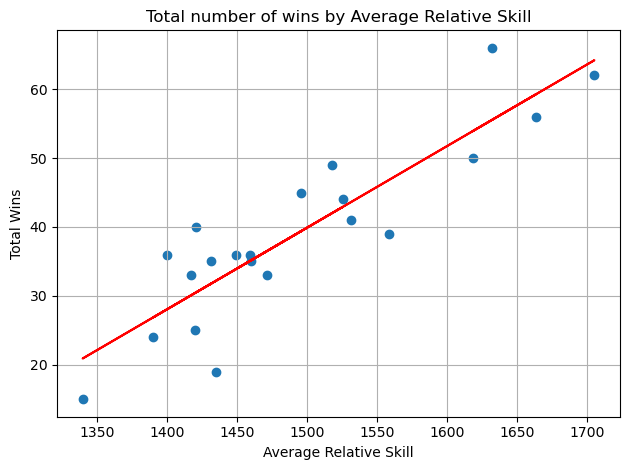

```
Correlation between avg_elo_n and total_wins:
 Peasron Correlation: 0.8851
 Two-Tailed p-value:  0.0000

Reject the null hypothesis: p-value 0.0000 < significance level 0.01
There is a significant correlation between avg_elo_n and total_wins
```

```python
# run methods
plot_metrics(nba_wins_df, 'avg_elo_n', 'total_wins', 'Total number of wins by Average Relative Skill', 'Average Relative Skill', 'Total Wins')
correlation_metrics(nba_wins_df, 'avg_elo_n', 'total_wins', alpha = 0.01)
```